# writeup

Zhuoyi Zhan

October 22, 2021

# 1 Introduction

gamma distribution is a one of the continuous probability distribution with two positive parameters, shape and scale. The skewness of the gamma distribution depends on shape parameter. The mean scales is equal to shape*scale. dgamma gives the density and qgamma gives the the quantile function. The medium of gamma distribution is also the interval of 50th percent. So it can be calculated by qgamma(0.5, shape, scale)

log-normal distribution is distribution of a random variable whose logarithm is distributed normally. The log-noraml distribution has a mean and standard deviation as parameters. Its mean is expoential of mean plus one half of squared standard deviation.

Uniform distribution lies between the minimum and maximum bounds. the same length on the distribution has equal probability. The mean is the middle point of min and max.

A PDF is a probability density function that shows probability of a random variable within a range. A cumulative distribution function, CDF, shows the probability of a value less than or equal to x.

## 1.1 For each distribution below, generate a figure of the PDF and CDF. Mark the mean and median in the figure.

X ∼ GAMMA(shape = 3, scale = 1)

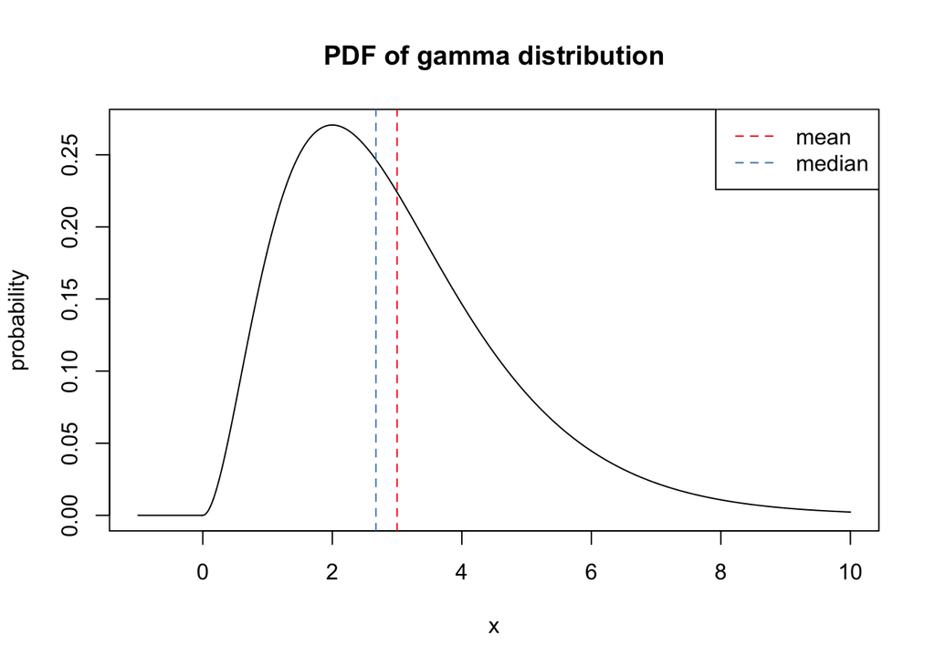

```r
x <- seq(-1,10,by=0.01)

pdfg <- dgamma(x,shape =3, scale=1)
cdfg <- pgamma(x,shape =3, scale=1)

mean<- 3*1
med <- qgamma(0.5,shape =3, scale=1)

plot(x,pdfg,main="PDF of gamma distribution",
  xlab="x", ylab="probability",type = "l")
abline(v=c(mean,med), lty=2,col=c("red","steel blue"))
legend("topright", c("mean","median"), col=c("red", "steelblue"), lty=c(2,2))
```

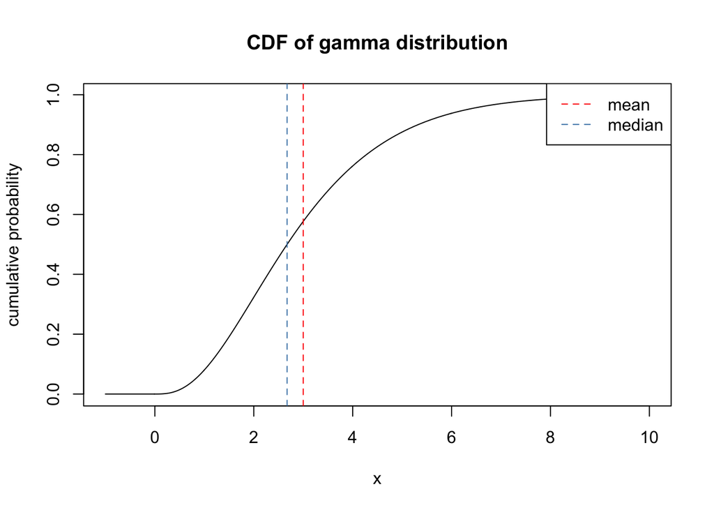

```r
plot(x,cdfg,main="CDF of gamma distribution",
  xlab="x", ylab="cumulative probability",type="l")
abline(v=c(mean,med), lty=2,col=c("red","steel blue"))
legend("topright", c("mean","median"), col=c("red", "steelblue"), lty=c(2,2))
```

Analytical method is used to generate the plots. The mean is 3 and the median is 2.674. The shape of gamma distribution first increase then decrease to 0.

X ∼ LOG NORMAL(μ = − 1, σ = 1)

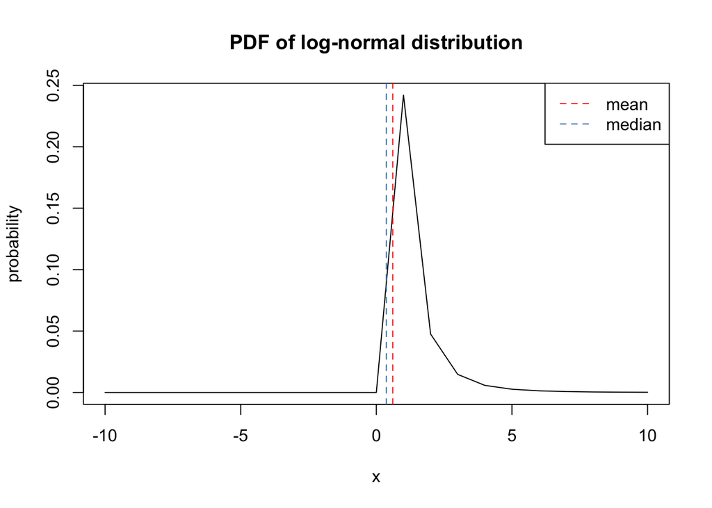

```r
x <- c(-10:10)
y <- dlnorm(x,meanlog=-1, sdlog=1)
y1 <- plnorm(x,meanlog=-1, sdlog=1)
y_mean <- exp(-1+1^2/2)
y_med <- qlnorm(0.5,-1,1)

plot(x,y,type="l",main="PDF of log-normal distribution",
  xlab="x", ylab="probability")
abline(v=c(y_mean,y_med), lty=2,col=c("red","steel blue"))
legend("topright", c("mean","median"), col=c("red", "steelblue"), lty=c(2,2))
```

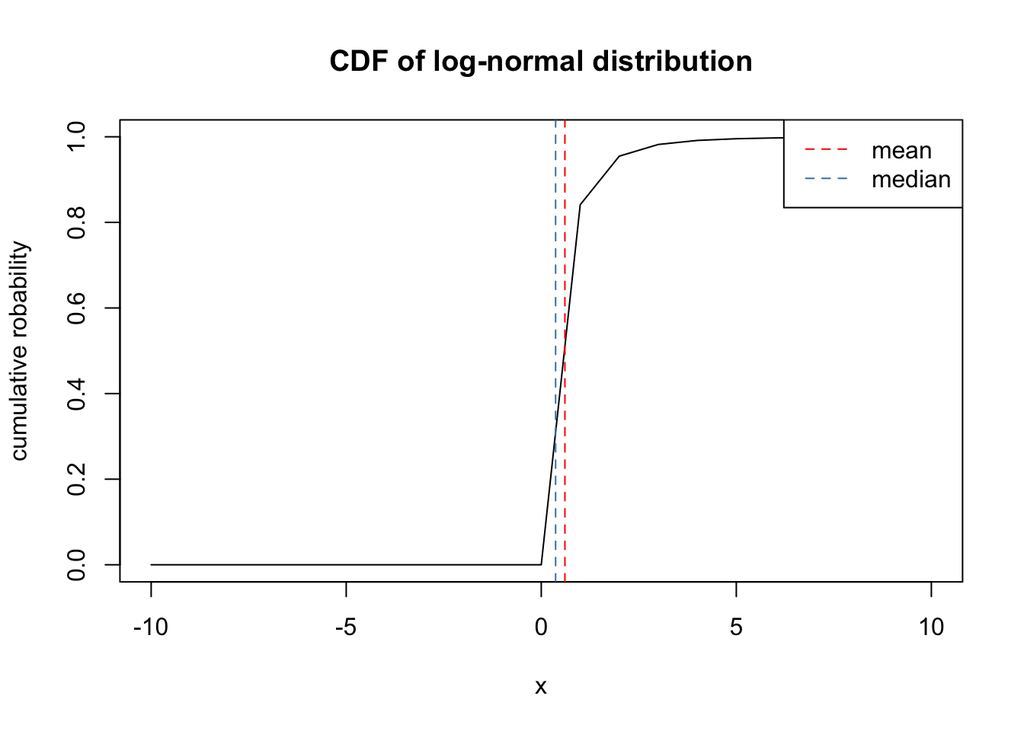

```r
plot(x,y1,type="l",main="CDF of log-normal distribution",
  xlab="x", ylab="cumulative robability")
abline(v=c(y_mean,y_med), lty=2,col=c("red","steel blue"))
legend("topright", c("mean","median"), col=c("red", "steelblue"), lty=c(2,2))
```

The mean is 0.60653 and the median is 0.3678794. The shape of log distribution increase from 0, peaks around 1 and then decrease to 0.

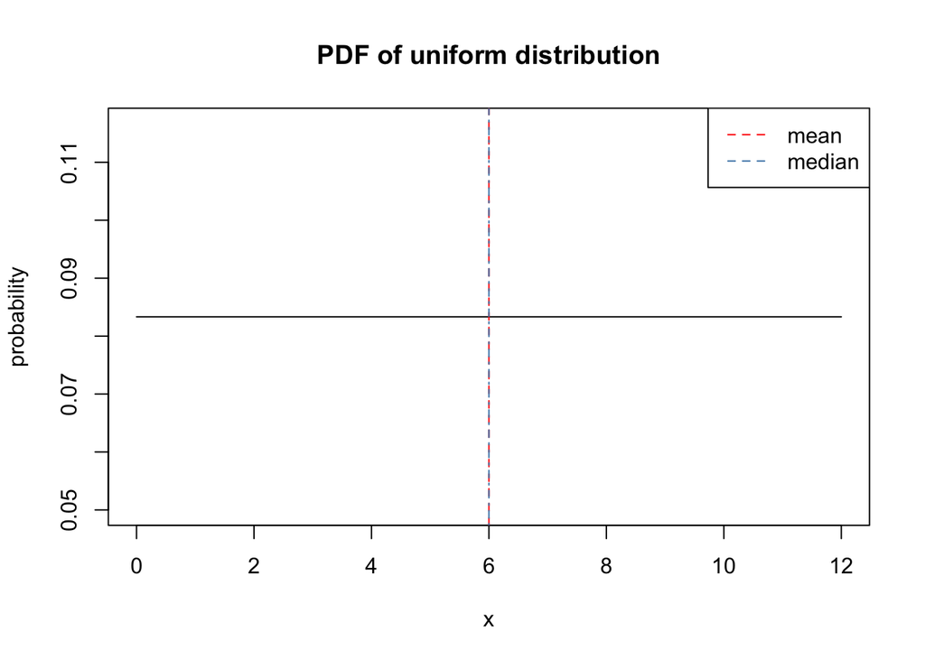

```r
x <- seq(0,12)
y<-dunif(x, min=0, max=12)
y2=punif(x, min=0, max=12)
ymean <- 1/2*(0+12)
ymed<- qunif(0.5, min=0, max=12)
plot(x,y,type="l",main="PDF of uniform distribution",
  xlab="x", ylab="probability")
abline(v=c(ymean,ymed), lty=c(2,4),col=c("red","steel blue"))
legend("topright", c("mean","median"), col=c("red", "steelblue"), lty=c(2,2))
```

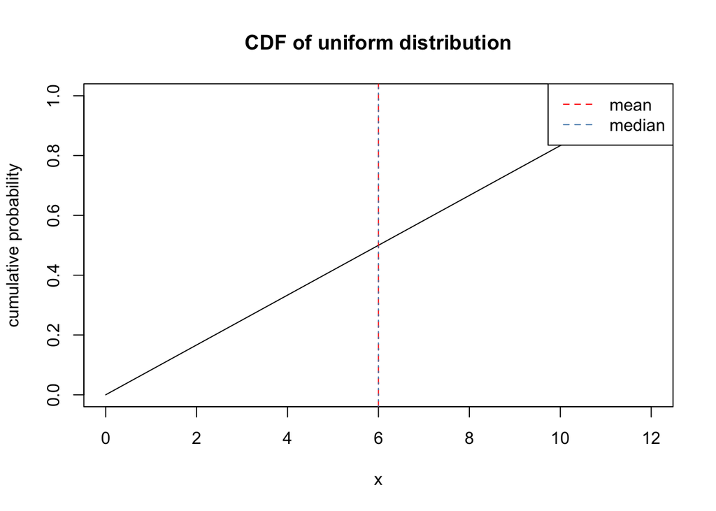

```r
plot(x, y2,type="l",main="CDF of uniform distribution",
  xlab="x", ylab="cumulative probability")
abline(v=c(ymean,ymed), lty=c(2,3),col=c("red","steel blue"))
legend("topright", c("mean","median"), col=c("red", "steelblue"), lty=c(2,2))
```

The mean is 6 and the median is also 6. When x is within 0 to 12, all x values has the same probrbility

## 1.2 For each distribution below, generate a figure of the PDF and CDF of the transformation Y = log(X) random variable. Mark the mean and median in the figure. You may use simulation or analytic methods in order find the PDF and CDF of the transformation.

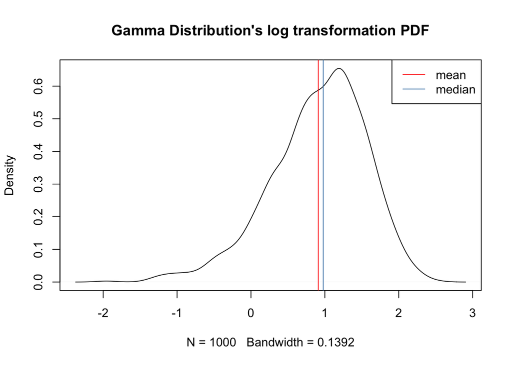

```r
x <- rgamma(1000,shape=3,scale=1)
#log transformation
Y <- log(x)
plot(density(Y), type="l", main="Gamma Distribution's log transformation PDF")
abline(v=mean(Y),col="red")
abline(v=median(Y),col="steelblue")
legend("topright", c("mean","median"), col=c("red", "steelblue"), lty=c(1,1))
```

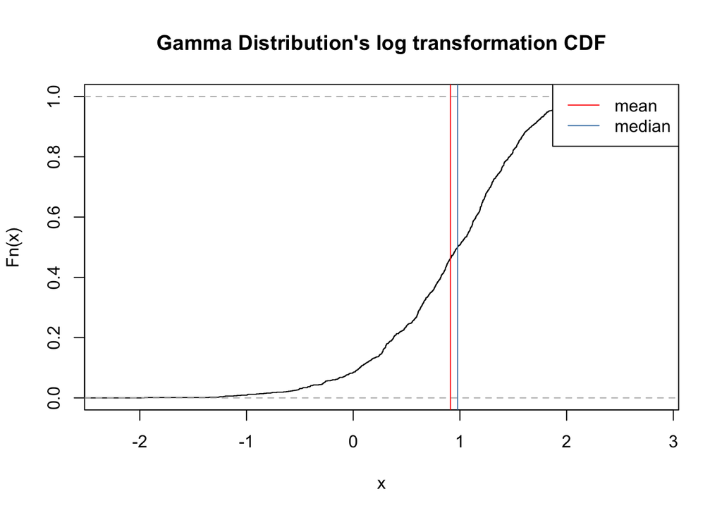

```r
#plot CDF for Gamma distribution log transformation
plot(ecdf(Y),main="Gamma Distribution's log transformation CDF")
abline(v=mean(Y),col="red")
abline(v=median(Y),col="steelblue")
legend("topright", c("mean","median"), col=c("red", "steelblue"), lty=c(1,1))
```

Gamma Distribution’s log transformation The mean is 0.8865 and the median is 0.9475652.

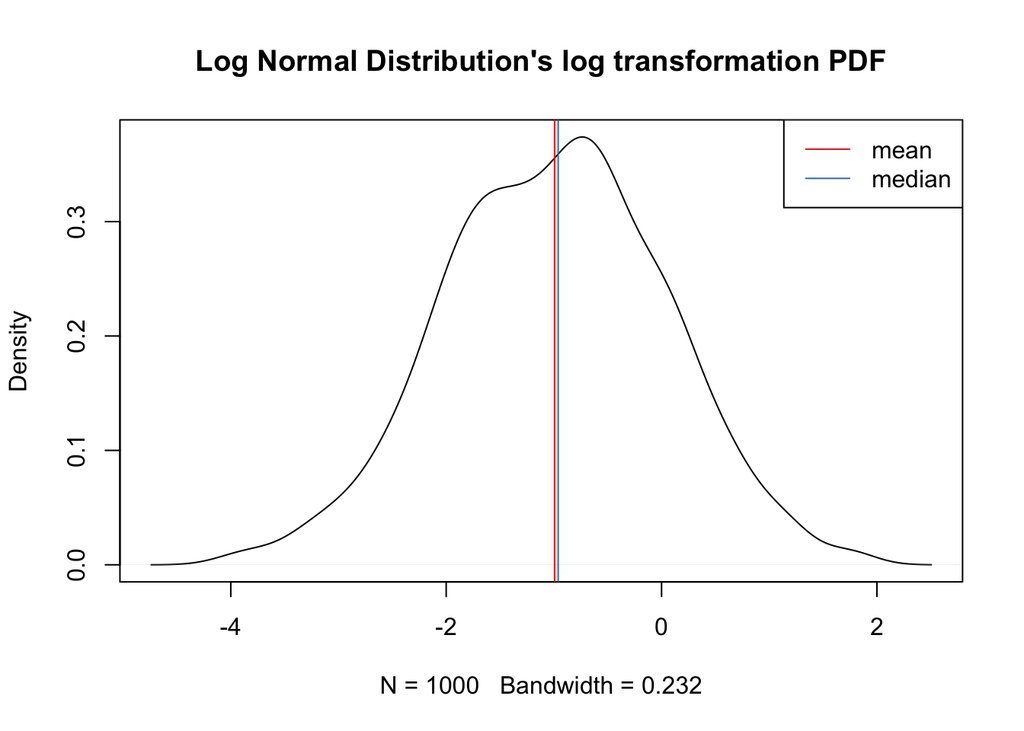

```r
x <- rlnorm(1000, meanlog=-1, sdlog=1)
Y <- log(x)
#plot PDF for Log normal distribution
plot(density(Y), type="l", main="Log Normal Distribution's log transformation PDF")
abline(v=mean(Y),col="red")
abline(v=median(Y),col="steelblue")
legend("topright", c("mean","median"), col=c("red", "steelblue"), lty=c(1,1))
```

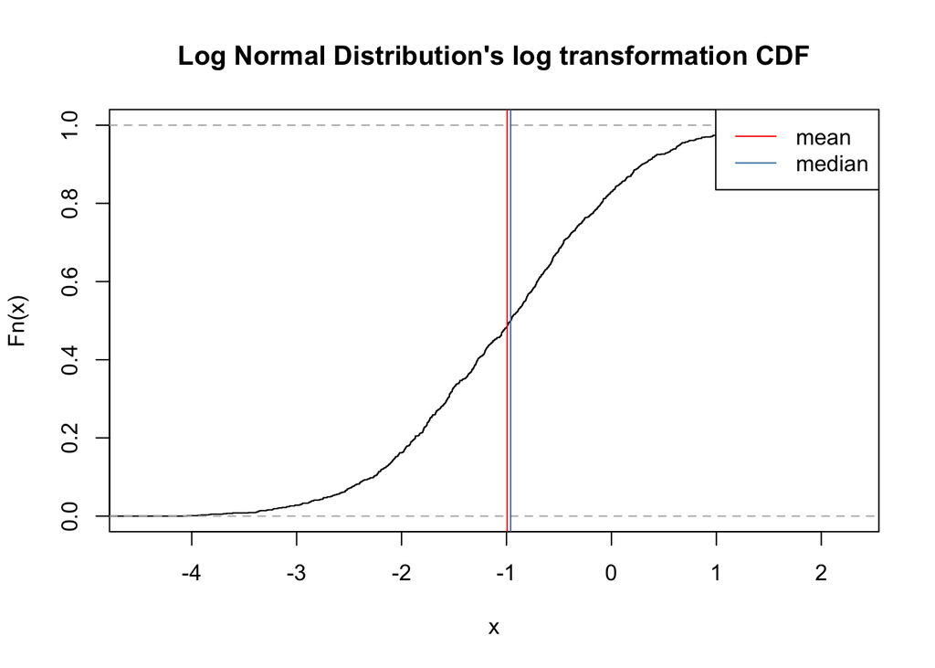

```r
#plot CDF for log normal distribution log transformation
plot(ecdf(Y),main="Log Normal Distribution's log transformation CDF")
abline(v=mean(Y),col="red")
abline(v=median(Y),col="steelblue")
legend("topright", c("mean","median"), col=c("red", "steelblue"), lty=c(1,1))
```

Log Normal Distribution’s log transformation The mean is -1.02 and the median is -1.01.

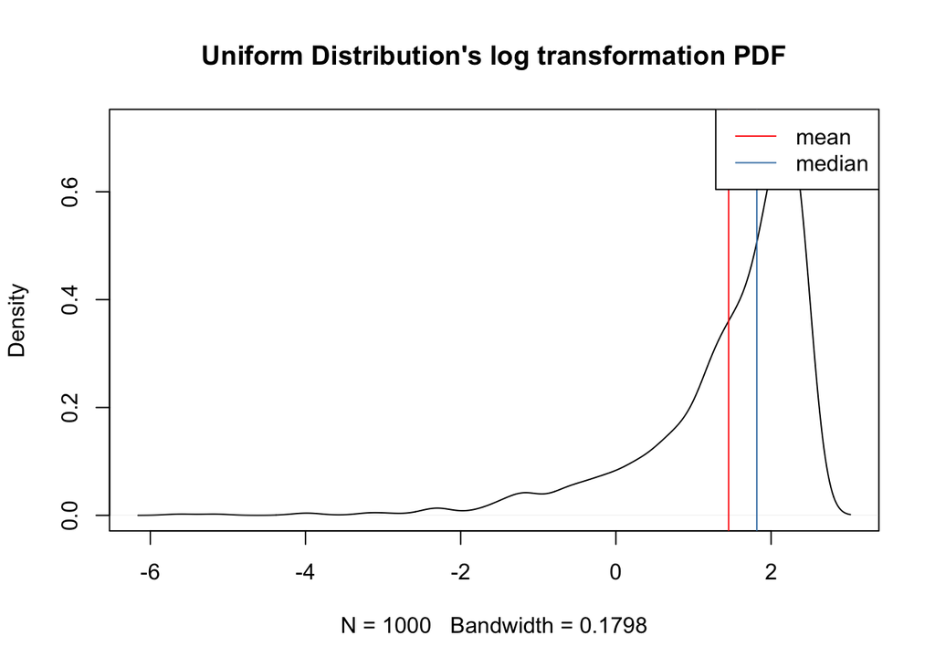

```r
x <- runif(1000, min=0, max=12)
Y <- log(x)
#plot PDF for uniform distribution
plot(density(Y), type="l", main="Uniform Distribution's log transformation PDF")
abline(v=mean(Y),col="red")
abline(v=median(Y),col="steelblue")
legend("topright", c("mean","median"), col=c("red", "steelblue"), lty=c(1,1))
```

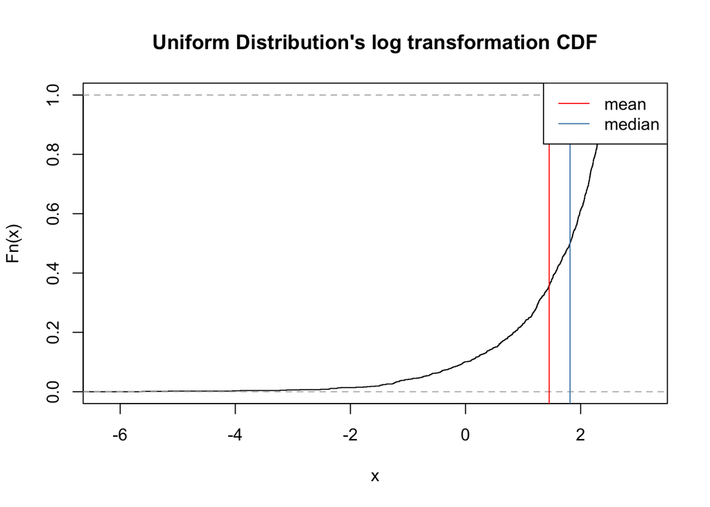

```r
#plot CDF for uniform distribution log transformation
plot(ecdf(Y),main="Uniform Distribution's log transformation CDF")
abline(v=mean(Y),col="red")
abline(v=median(Y),col="steelblue")
legend("topright", c("mean","median"), col=c("red", "steelblue"), lty=c(1,1))
```

Uniform Distribution’s log transformation: The mean is 1.528, the median is 1.8356.

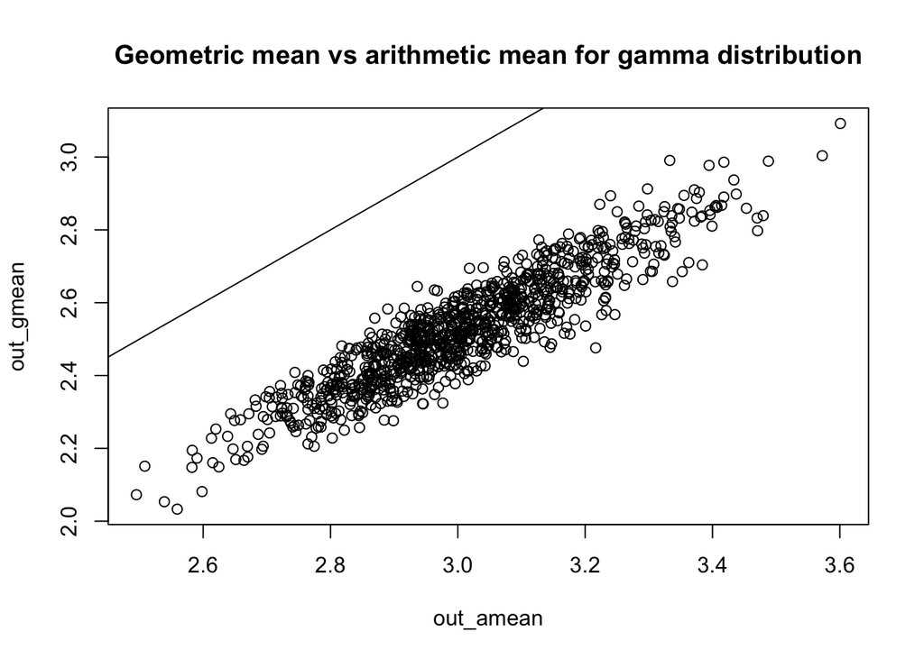

```r
out_gmean <- rep(NA, 1000)
out_amean <- rep(NA, 1000)

shape=3
scale=1
for (i in 1:1000){
  rec <- rgamma(0:100, shape=3, scale=1)
  out_gmean[i] <- exp(mean(log(rec)))
  out_amean[i] <- mean(rec)
}

plot(out_amean,out_gmean,main="Geometric mean vs arithmetic mean for gamma distribution")
abline(a=0,b=1)
```

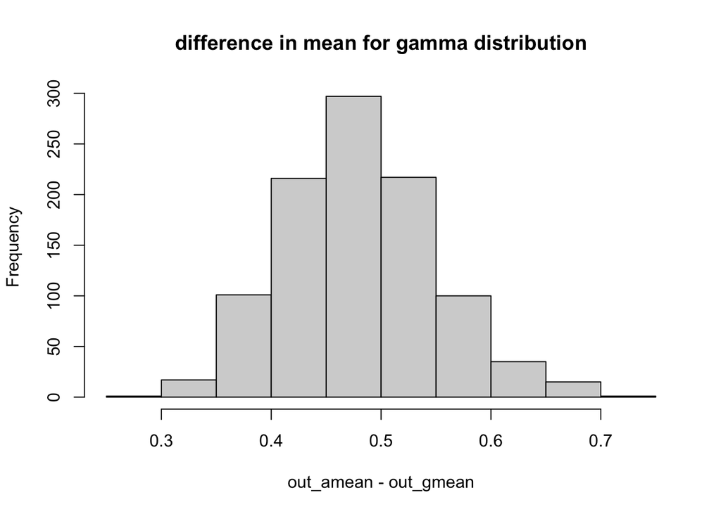

```r
hist(out_amean-out_gmean, main="difference in mean for gamma distribution")
```

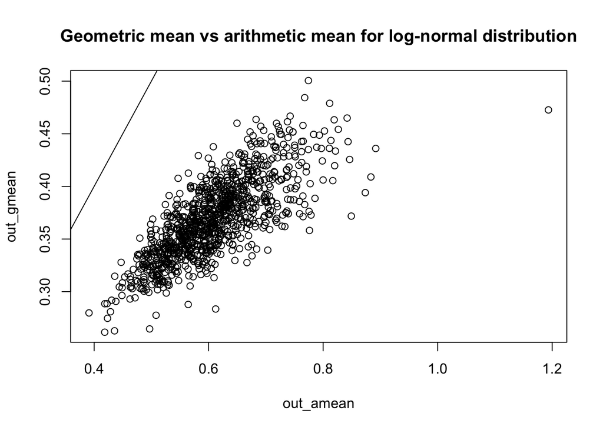

```r
out_gmean <- rep(NA, 1000)
out_amean <- rep(NA, 1000)
for (i in 1:1000){
  rec<- rlnorm(0:100, meanlog = -1,sdlog = 1)
  out_gmean[i] <- exp(mean(log(rec)))
  out_amean[i] <- mean(rec)
}
plot(out_amean,out_gmean,main="Geometric mean vs arithmetic mean for log-normal distribution")
abline(a=0,b=1)
```

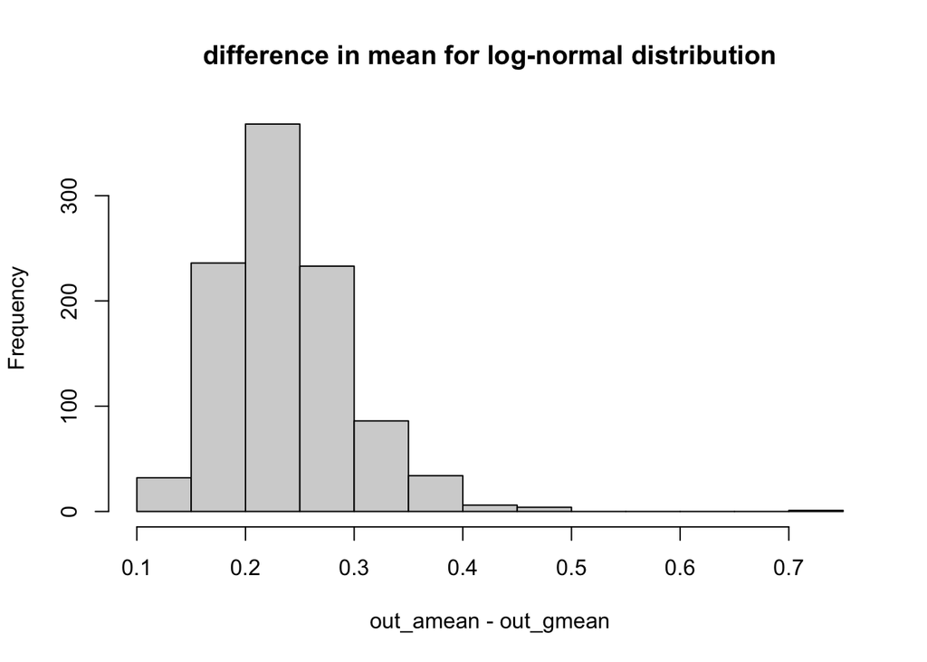

```r
hist(out_amean-out_gmean,main="difference in mean for log-normal distribution")
```

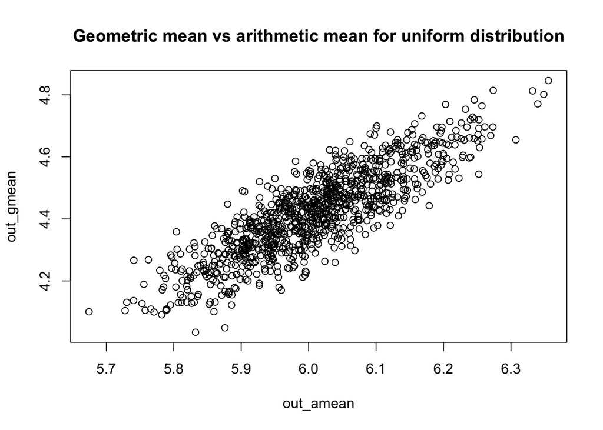

```r
out_gmean <- rep(NA, 1000)
out_amean <- rep(NA, 1000)

min=0
max=12
for (i in 1:1000){
  rec<-runif(x,min, max)
  out_gmean[i]<- exp(mean(log(rec)))
  out_amean[i]<- mean(rec)
}
plot(out_amean,out_gmean,main="Geometric mean vs arithmetic mean for uniform distribution")
abline(a=0,b=1)
```

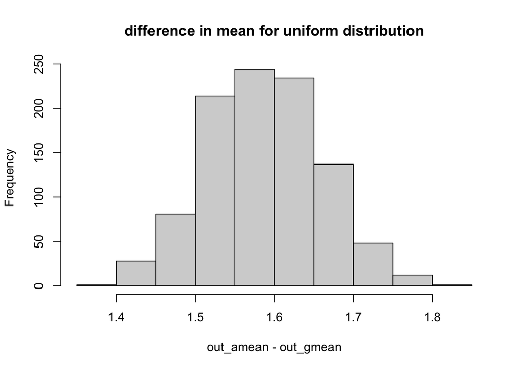

```r
hist(out_amean-out_gmean,main="difference in mean for uniform distribution")
```

## 1.3 What is the correct relationship between E[log (X)] and log (E[X])? Is one always larger? Equal? Explain your answer.

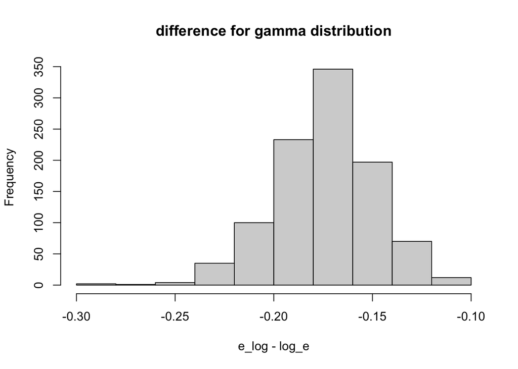

```r
e_log <- rep(NA, 1000)
log_e <- rep(NA, 1000)

shape=3
scale=1
for (i in 1:1000){
  z <- rgamma(0:100, shape=3, scale=1)
  log_z <- log(z)
  e_log[i] <- mean(log_z)
  log_e[i] <- log(mean(z))
}
hist(e_log-log_e,main="difference for gamma distribution")
```

E[log (X)] is always smaller than log (E[X]) since it is a neagative differnce.

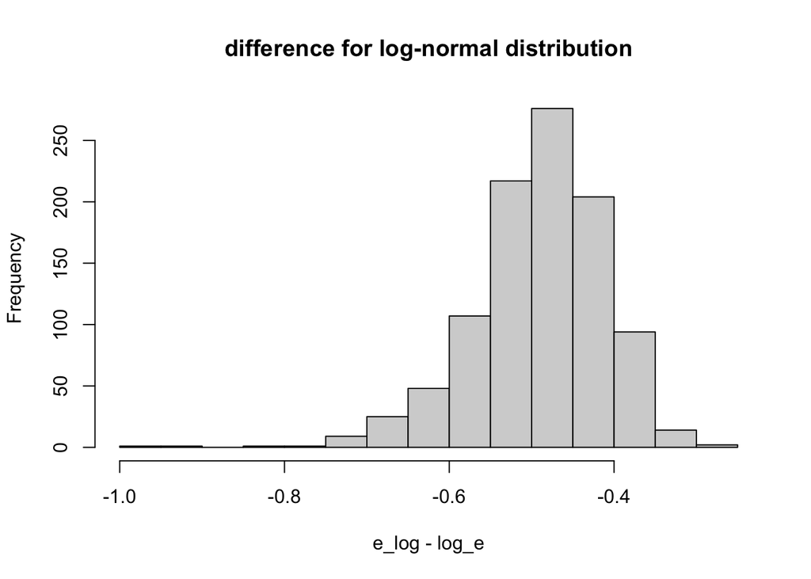

```r
e_log <- rep(NA, 1000)
log_e <- rep(NA, 1000)

for (i in 1:1000){
  z <- rlnorm(0:100, meanlog = -1,sdlog = 1)
  log_z <- log(z)
  e_log[i] <- mean(log_z)
  log_e[i] <- log(mean(z))
}
hist(e_log-log_e,main="difference for log-normal distribution")
```

E[log (X)] is always smaller than log (E[X]) because the E[log (X)] - log (E[X]) is neagtive

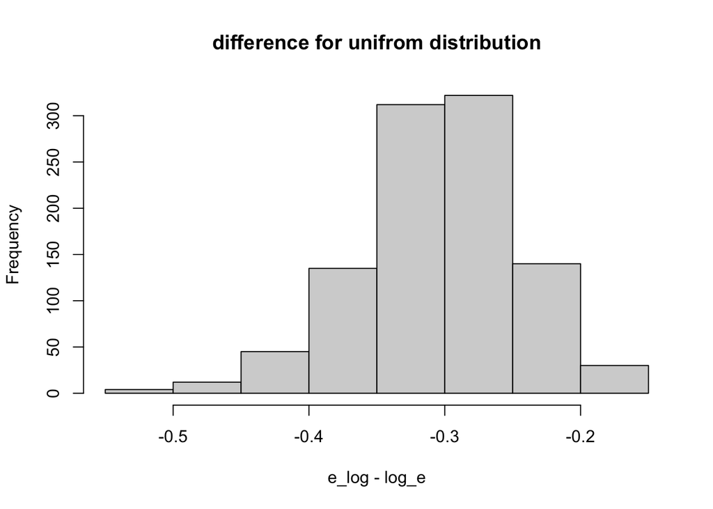

```r
e_log <- rep(NA, 1000)
log_e <- rep(NA, 1000)

for (i in 1:1000){
  z <- runif(0:100, min=0,max=12)
  log_z <- log(z)
  e_log[i] <- mean(log_z)
  log_e[i] <- log(mean(z))
}
hist(e_log-log_e,main="difference for unifrom distribution")
```

E[log (X)] is always smaller than log (E[X]) because the E[log (X)] - log (E[X]) is neagtive.